# Juhasz_replication

Thomas Bombarde

2024-01-16

# Setup

# Pre-trends

Before running let’s understand the changes in areas thought treated vs not treated before the introduction of the blockade, e.g. checking for pre-trends. The following Figure displays the relationship between distance to Britain through smuggling roots used in 1807

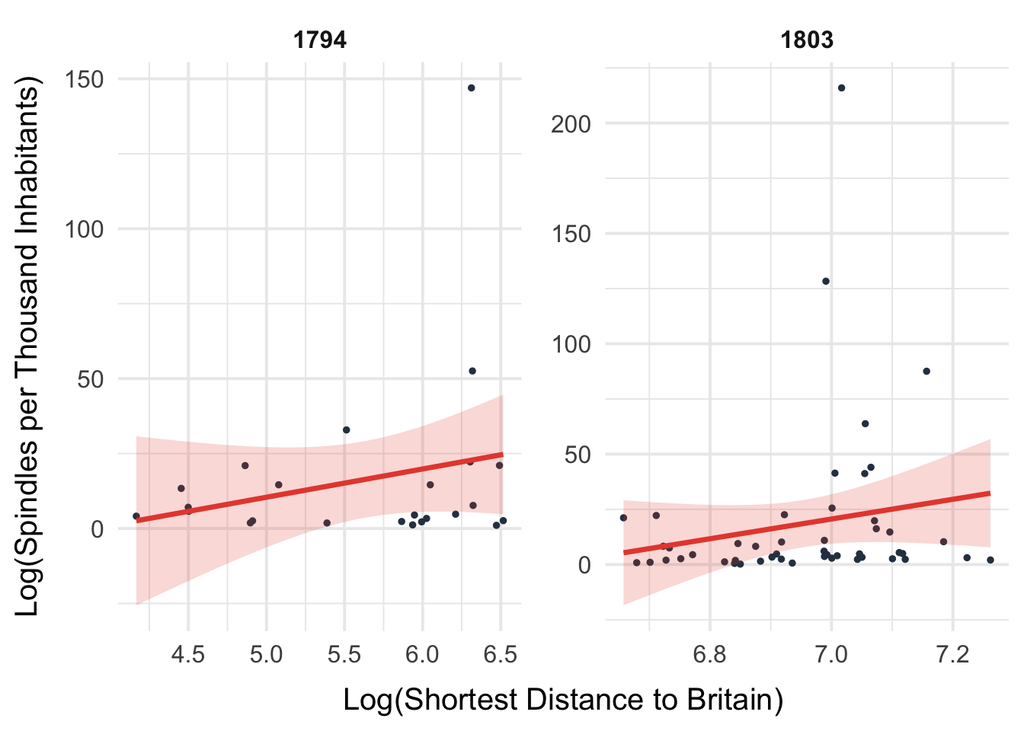

```r
prepre_relation_plot <- ggplot(department_pretreatment_panel %>%
                                 filter(thspindles!=0),
                            aes(x = lnshortestLo, y = thspindles)) +
  geom_point(size = 1, color = "#2c3e50", alpha = 1)+
  geom_smooth(method = "lm",
              color = "#e74c3c",  # Use a bold red color for the line
              fill = "#e74c3c",   # Fill the confidence interval with a lighter red shade
              alpha = .2,        # Add transparency to the fill for subtle effect
              size = 1.2,         # Make the line slightly thicker
              se = TRUE) +
  facet_wrap(~year, scale="free") +
  facet_wrap(~year, scales="free") +
  labs(
    x = "Log(Shortest Distance to Britain)",
    y = "Log(Spindles per Thousand Inhabitants)"
  ) +
  theme_minimal(base_size = 15) +  # Use a clean minimal theme
  theme(
    plot.title = element_text(hjust = 0.5, face = "bold", size = 18),  # Center and enlarge title
    axis.title.x = element_text(margin = margin(t = 10)),  # Add space between labels and axis
    axis.title.y = element_text(margin = margin(r = 10)),
    strip.background = element_blank(),  # Remove background for facets
    strip.text = element_text(size = 12, face = "bold"),  # Bold facet labels
    panel.spacing = unit(1, "lines"),  # Increase spacing between facets
    legend.position = "none"  # Remove legend (since it's not needed)
  )
print(prepre_relation_plot)
```

```r
#+
  #theme(text = element_text(family="serif"))
```

There doesn’t seem to be strong evidence of a positive linear relationship. We can see this when run the model below. There is considerable jump in the average effect of being further from Great Britain, but this is not significant.

```r
model <- plm(thspindles ~ year*lnshortestLo, data=department_pretreatment_panel, index=c("year", "department"))
summary(model)
```

```
## Oneway (individual) effect Within Model
##
## Call:
## plm(formula = thspindles ~ year * lnshortestLo, data = department_pretreatment_panel,
##     index = c("year", "department"))
##
## Balanced Panel: n = 2, T = 88, N = 176
##
## Residuals:
##     Min.  1st Qu.   Median  3rd Qu.     Max.
## -16.6842  -7.6407  -4.7390  -1.9759 203.9531
##
## Coefficients:
##                       Estimate Std. Error t-value Pr(>|t|)
## lnshortestLo            1.9890     4.0194  0.4948   0.6213
## year1803:lnshortestLo  22.1246    16.6817  1.3263   0.1865
##
## Total Sum of Squares:    100600
## Residual Sum of Squares: 99182
## R-Squared:      0.014119
## Adj. R-Squared: -0.0030771
## F-statistic: 1.23158 on 2 and 172 DF, p-value: 0.29439
```

# Short-run

Did industry protection against smuggled English goods during the Napoleonic blockade increase spindle-accumulation?

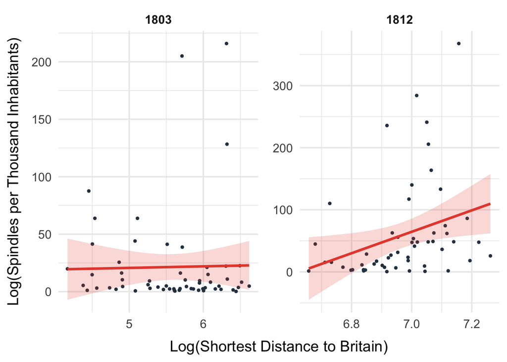

```r
ggplot(department_shortrun_panel.dta %>%
         filter(thspindles!=0),
       aes(x=lnshortestLo, y= thspindles)) +
  geom_point(size = 1, color = "#2c3e50", alpha = 1) +
  geom_smooth(method = "lm",
              color = "#e74c3c",  # Use a bold red color for the line
              fill = "#e74c3c",   # Fill the confidence interval with a lighter red shade
              alpha = .2,        # Add transparency to the fill for subtle effect
              size = 1.2,         # Make the line slightly thicker
              se = TRUE) +
  facet_wrap(~year, scale="free") +
  labs(
    x = "Log(Shortest Distance to Britain)",
    y = "Log(Spindles per Thousand Inhabitants)"
  ) +
  theme_minimal(base_size = 15) +  # Use a clean minimal theme
  theme(
    plot.title = element_text(hjust = 0.5, face = "bold", size = 18),  # Center and enlarge title
    axis.title.x = element_text(margin = margin(t = 10)),  # Add space between labels and axis
    axis.title.y = element_text(margin = margin(r = 10)),
    strip.background = element_blank(),  # Remove background for facets
    strip.text = element_text(size = 12, face = "bold"),  # Bold facet labels
    panel.spacing = unit(1, "lines"),  # Increase spacing between facets
    legend.position = "none"  # Remove legend (since it's not needed)
  )
```

Looks better! What does this say numerically? We run the Difference in Difference type model as the number of spindles regressed on year fixed effects and the shortest distance of that year

```r
model <- plm(thspindles ~ year + lnshortestLo, data=department_shortrun_panel.dta, model = "within", effect = "individual")#
sumshortrun <- summary(model)
sumshortrun
```

```
## Oneway (individual) effect Within Model
##
## Call:
## plm(formula = thspindles ~ year + lnshortestLo, data = department_shortrun_panel.dta,
##     effect = "individual", model = "within")
##
## Unbalanced Panel: n = 107, T = 1-2, N = 195
##
## Residuals:
##      Min.   1st Qu.    Median   3rd Qu.      Max.
## -102.1990   -8.2303    0.0000    8.2303  102.1990
##
## Coefficients:
##              Estimate Std. Error t-value  Pr(>|t|)
## year1812     -14.6439     9.9169 -1.4767    0.1434
## lnshortestLo  33.4657     7.1552  4.6772 1.071e-05 ***
## ---
## Signif. codes:  0 '***' 0.001 '**' 0.01 '*' 0.05 '.' 0.1 ' ' 1
##
## Total Sum of Squares:    153290
## Residual Sum of Squares: 100280
## R-Squared:      0.3458
## Adj. R-Squared: -0.47576
## F-statistic: 22.729 on 2 and 86 DF, p-value: 1.1901e-08
```

```r
lnshortestLo_coef <- sumshortrun$coefficients[2,1]
```

Before the treatment, there is no relationship between effective distance to the UK and spindle density. Afterhand, a 100% increase in effective distance adds a whopping 33.4657443 increase to the number of spindles/inhabitant! We’re assuming people aren’t flooding to cities as close as possible to the enemy, so the change should be coming from greater mechanisation, in line with the infant industry argument.

There are caveats we should check, and ways we can make this relationship stronger. Variables that might add drown out our results are

- Obligatory conscription, which might decrease our population estimates.
- Growing market access, the inverse of summed distance to cities scaled for département population, which might also have faciliated new technology adoption.
- Migration of knowledge elites away from the Englishm or perhaps less demands in cities closer to the enemy? we can control for knowledge access and literacy in 1812.
- coal, which rises in importance with the industrialisation of the period.

Juhasz adds these one by one in her regression, and checks that effective distance is significant in each. Adding them all in, we get

```r
model <- plm(thspindles ~ year + lnshortestLo +
               lnstreamflowX1812 +
               lncoalX1812 +
               lnma_universityX1812 +
               lnma_urbanX1812 +
               literacyX1812,
             data=filter(department_shortrun_panel.dta,is.na(literacyX1812)==F), model = "within", effect = "individual")
sumshortrun <- summary(model)
sumshortrun
```

```
## Oneway (individual) effect Within Model
##
## Call:
## plm(formula = thspindles ~ year + lnshortestLo + lnstreamflowX1812 +
##     lncoalX1812 + lnma_universityX1812 + lnma_urbanX1812 + literacyX1812,
##     data = filter(department_shortrun_panel.dta, is.na(literacyX1812) ==
##         F), effect = "individual", model = "within")
##
## Unbalanced Panel: n = 77, T = 1-2, N = 140
##
## Residuals:
##     Min.  1st Qu.   Median  3rd Qu.     Max.
## -95.3047  -8.4415   0.0000   8.4415  95.3047
##
## Coefficients:
##                       Estimate Std. Error t-value Pr(>|t|)
## year1812             -300.7099   337.6103 -0.8907 0.376900
## lnshortestLo           38.8183    11.1840  3.4709 0.001006 **
## lnstreamflowX1812      -1.1591     3.4043 -0.3405 0.734765
## lncoalX1812             4.1112     7.0188  0.5857 0.560400
## lnma_universityX1812   34.8954    27.9872  1.2468 0.217648
## lnma_urbanX1812        30.1876    32.2008  0.9375 0.352539
## literacyX1812          27.7925    28.8639  0.9629 0.339746
## ---
## Signif. codes:  0 '***' 0.001 '**' 0.01 '*' 0.05 '.' 0.1 ' ' 1
##
## Total Sum of Squares:    130850
## Residual Sum of Squares: 67844
## R-Squared:      0.48152
## Adj. R-Squared: -0.28694
## F-statistic: 7.4297 on 7 and 56 DF, p-value: 2.6392e-06
```

```r
lnshortestLo_coef <- sumshortrun$coefficients[2,1]
```

With these controls, our estimated effect is greater, if negligibly less significant. So far, we have assumed the relationship between effective distance and increased spindles is driven by the increase in smuggling costs, acting throughs the infant-industry argument. However, we should consider two other shocks in this period:

A. a rise in prices of raw cotton

B. the expansion of the French Empire.

These two developments could have the same spatial effects as the increase cotton good prices, and make our regression spurious.

Addressing A, Juhasz (2018) maps price data in north and southern France. She argues that this is fairly uniform, and that this should be expected given that the rise in prices was due to a rise in tariffs. What about the smuggling routes for raw cotton?

1. Juhasz (2018) claims that little raw cotton was purchased from Britain. Even if they did, smuggling would arguably work in the favour of the infant industry arguement, because raw cotton and cotton goods would have taken the same route. Given that cotton inputs and goods were both cheaper, which effect dominates? The regression just would support the latter. We’ll take the argument that cotton prices increase uniformly over France for granted.
2. Raw cotton was often brought in by land, from Portugal and the Levant. These were not affectd by the blockade. A simulataneous shock Juhasz (2018) does not address is the role of Portugal as an opponent of the Napoleonic Regime, which is a question for someone with more historical knowledge than me.

Addressing B – that what might be increasing French industrialisation is access to markets in Europe through Napoleon’s invasion – Juhasz includes a measure of market potential to European cities within the French Empire. She later extends this with access to markets within France’s sphere of influence, as defined by Grab (2003).

```r
model <- plm(thspindles ~ year + lnshortestLo +
               lnma_urban_externalX1812, #lnma_urbanX1812:access to european markets
             data=department_shortrun_panel.dta,
             model = "within",
             effect = "individual")
summary(model)
```

```
## Oneway (individual) effect Within Model
##
## Call:
## plm(formula = thspindles ~ year + lnshortestLo + lnma_urban_externalX1812,
##     data = department_shortrun_panel.dta, effect = "individual",
##     model = "within")
##
## Unbalanced Panel: n = 107, T = 1-2, N = 195
##
## Residuals:
##      Min.   1st Qu.    Median   3rd Qu.      Max.
## -101.8962   -8.5437    0.0000    8.5437  101.8962
##
## Coefficients:
##                          Estimate Std. Error t-value Pr(>|t|)
## year1812                 -386.295    414.328 -0.9323  0.35380
## lnshortestLo               40.562     10.671  3.8012  0.00027 ***
## lnma_urban_externalX1812   40.044     44.629  0.8973  0.37212
## ---
## Signif. codes:  0 '***' 0.001 '**' 0.01 '*' 0.05 '.' 0.1 ' ' 1
##
## Total Sum of Squares:    153290
## Residual Sum of Squares: 99343
## R-Squared:      0.35194
## Adj. R-Squared: -0.47911
## F-statistic: 15.3867 on 3 and 85 DF, p-value: 4.4293e-08
```

However, this assumes that the effect of market access and protection from British imports are independent. One might imagine that protection from british goods locally is important for the perseverance of local industry, but access to larger (foreign) markets is necessary for domestic industry’s expansion. Thus, given protection from British goods, the increase in industrialisation might still be increasing in access to foreign markets. This should be captured by the interaction term between access to foreign continental markets and import exposure. I add this to Juhasz’s specification.

```r
model <- plm(thspindles ~ year + lnshortestLo*lnma_urban_externalX1812, #lnma_urbanX1812:access to european markets
             data=department_shortrun_panel.dta,
             model = "within",
             effect = "individual")
sumshortrun <- summary(model)
sumshortrun
```

```
## Oneway (individual) effect Within Model
##
## Call:
## plm(formula = thspindles ~ year + lnshortestLo * lnma_urban_externalX1812,
##     data = department_shortrun_panel.dta, effect = "individual",
##     model = "within")
##
## Unbalanced Panel: n = 107, T = 1-2, N = 195
##
## Residuals:
##      Min.   1st Qu.    Median   3rd Qu.      Max.
## -101.9397   -7.7176    0.0000    7.7176  101.9397
##
## Coefficients:
##                                        Estimate Std. Error t-value  Pr(>|t|)
## year1812                              -371.2635   420.1169 -0.8837 0.3793725
## lnshortestLo                            41.7327    11.5315  3.6190 0.0005042
## lnma_urban_externalX1812                46.9754    51.3799  0.9143 0.3631883
## lnshortestLo:lnma_urban_externalX1812   -1.2583     4.5427 -0.2770 0.7824696
##
## year1812
## lnshortestLo                          ***
## lnma_urban_externalX1812
## lnshortestLo:lnma_urban_externalX1812
## ---
## Signif. codes:  0 '***' 0.001 '**' 0.01 '*' 0.05 '.' 0.1 ' ' 1
##
## Total Sum of Squares:    153290
## Residual Sum of Squares: 99252
## R-Squared:      0.35253
## Adj. R-Squared: -0.49535
## F-statistic: 11.4339 on 4 and 84 DF, p-value: 1.8625e-07
```

```r
lnshortestLo_coef <- sumshortrun$coefficients[2,1]
```

```r
model <- plm(thspindles ~ year + lnshortestLo +
               lnstreamflowX1812 +
               lncoalX1812 +
               lnma_universityX1812 +
               lnma_urbanX1812 +
               literacyX1812 +
               lnshortestLo*lnma_urban_externalX1812,
             data=filter(department_shortrun_panel.dta,is.na(literacyX1812)==F), model = "within", effect = "individual")
sumshortrun <- summary(model)
sumshortrun
```

```
## Oneway (individual) effect Within Model
##
## Call:
## plm(formula = thspindles ~ year + lnshortestLo + lnstreamflowX1812 +
##     lncoalX1812 + lnma_universityX1812 + lnma_urbanX1812 + literacyX1812 +
##     lnshortestLo * lnma_urban_externalX1812, data = filter(department_shortrun_panel.dta,
##     is.na(literacyX1812) == F), effect = "individual", model = "within")
##
## Unbalanced Panel: n = 77, T = 1-2, N = 140
##
## Residuals:
##     Min.  1st Qu.   Median  3rd Qu.     Max.
## -96.2443  -8.1218   0.0000   8.1218  96.2443
##
## Coefficients:
##                                          Estimate  Std. Error t-value Pr(>|t|)
## year1812                              -1714.89332  1439.17289 -1.1916   0.2386
## lnshortestLo                             65.87477    26.61750  2.4749   0.0165
## lnstreamflowX1812                        -0.76400     4.10875 -0.1859   0.8532
## lncoalX1812                               1.60900     7.45098  0.2159   0.8298
## lnma_universityX1812                     27.93820    29.67805  0.9414   0.3507
## lnma_urbanX1812                          33.90132    33.17379  1.0219   0.3114
## literacyX1812                            -1.76197    39.79448 -0.0443   0.9648
## lnma_urban_externalX1812                144.45168   129.09930  1.1189   0.2681
## lnshortestLo:lnma_urban_externalX1812     0.91432     9.65744  0.0947   0.9249
##
## year1812
## lnshortestLo                          *
## lnstreamflowX1812
## lncoalX1812
## lnma_universityX1812
## lnma_urbanX1812
## literacyX1812
## lnma_urban_externalX1812
## lnshortestLo:lnma_urban_externalX1812
## ---
## Signif. codes:  0 '***' 0.001 '**' 0.01 '*' 0.05 '.' 0.1 ' ' 1
##
## Total Sum of Squares:    130850
## Residual Sum of Squares: 66299
## R-Squared:      0.49333
## Adj. R-Squared: -0.30421
## F-statistic: 5.84202 on 9 and 54 DF, p-value: 1.19e-05
```

```r
lnshortestLo_coef <- sumshortrun$coefficients[2,1]
```

# Long-run

If the short-run increase in mechanisation really is driven by the opportunity of French départements to invest in industrial fixed-costs that increased their competitivity, then we should observe some persistence of higher productivity over time. Juhasz (2018) looks at the effect of increased cotton-spinning on both spinning capacity, and industrialization in 1840 and 1887. She runs the IV,

$$\begin{align}
S_{i1812} &= \alpha_0 + \beta_0 \text{D}_{i} + mathbf{X}
\mathbf{\gamma} \eta_{it} \\
Y_{it} &= \alpha + \beta \hat{S}_{it} + \mathbf{X} \mathbf{\gamma} +
\epsilon_{it},
\end{align}$$

where $i$ denotes département, $t$ year, $S_{i1812}$ is spindle capacity in 1812, $D_i$ is the change in trade costs imposed by the napoleonic blockade, and $\mathbf{X}$ is a set of controls.

The exclusion restriction requires that no other variables linked to the outcome $Y_{it}$ are correlated with the increase in trade cost. While this seem disputable given that smuggling routes could have had effects on the development of an informal/formal economy. To rebut this, Juhasz (2018) provides a placebo test using the pretreatment period, and lagged spinning capacity as a control, but she recognises that other shocks correlated with trade costs between 1812 and the outcome variable would confound results.

In the following, I do not use the same standard errors as Juhasz, but cluster these at the level of the observation.

```r
# Spindle capacity in 1840?
model <- ivreg(thspindles1840 ~ thspindles1812 + literacy + lnma_urban + lnma_university + lncoal + lnstreamflow + thspindles1803 | dlnshortestLo + literacy + lnma_urban + lnma_university + lncoal + lnstreamflow + thspindles1803, data=department_longrun_panel.dta)
summary(model)
```

```
##
## Call:
## ivreg(formula = thspindles1840 ~ thspindles1812 + literacy +
##     lnma_urban + lnma_university + lncoal + lnstreamflow + thspindles1803 |
##     dlnshortestLo + literacy + lnma_urban + lnma_university +
##         lncoal + lnstreamflow + thspindles1803, data = department_longrun_panel.dta)
##
## Residuals:
##      Min       1Q   Median       3Q      Max
## -319.201  -41.439   -2.966   30.742  556.179
##
## Coefficients:
##                 Estimate Std. Error t value Pr(>|t|)
## (Intercept)       73.140    932.074   0.078  0.93774
## thspindles1812     2.684      0.699   3.840  0.00032 ***
## literacy          60.982     78.059   0.781  0.43802
## lnma_urban       -15.751     89.905  -0.175  0.86157
## lnma_university -140.592     65.164  -2.158  0.03535 *
## lncoal           -27.427     17.974  -1.526  0.13275
## lnstreamflow     -10.449      8.699  -1.201  0.23485
## thspindles1803    -1.850      1.064  -1.739  0.08759 .
## ---
## Signif. codes:  0 '***' 0.001 '**' 0.01 '*' 0.05 '.' 0.1 ' ' 1
##
## Residual standard error: 122.8 on 55 degrees of freedom
## Multiple R-Squared: 0.653,   Adjusted R-squared: 0.6088
## Wald test: 7.911 on 7 and 55 DF,  p-value: 1.298e-06
```

```r
# Spindle capacity in 1887?
model <- ivreg(thspindles1887 ~ thspindles1812 + literacy + lnma_urban + lnma_university + lncoal + lnstreamflow + thspindles1803 | dlnshortestLo + literacy + lnma_urban + lnma_university + lncoal + lnstreamflow + thspindles1803, data=department_longrun_panel.dta)
summary(model)
```

```
##
## Call:
## ivreg(formula = thspindles1887 ~ thspindles1812 + literacy +
##     lnma_urban + lnma_university + lncoal + lnstreamflow + thspindles1803 |
##     dlnshortestLo + literacy + lnma_urban + lnma_university +
##         lncoal + lnstreamflow + thspindles1803, data = department_longrun_panel.dta)
##
## Residuals:
##      Min       1Q   Median       3Q      Max
## -758.729  -49.740    3.927   61.161  926.168
##
## Coefficients:
##                 Estimate Std. Error t value Pr(>|t|)
## (Intercept)     -135.261   1712.533  -0.079 0.937344
## thspindles1812     4.847      1.313   3.692 0.000527 ***
## literacy          -4.294    157.458  -0.027 0.978346
## lnma_urban       -16.379    164.961  -0.099 0.921282
## lnma_university -158.998    123.392  -1.289 0.203146
## lncoal            12.764     34.246   0.373 0.710853
## lnstreamflow     -17.537     16.132  -1.087 0.281913
## thspindles1803    -4.566      1.978  -2.308 0.024912 *
## ---
## Signif. codes:  0 '***' 0.001 '**' 0.01 '*' 0.05 '.' 0.1 ' ' 1
##
## Residual standard error: 228.2 on 53 degrees of freedom
## Multiple R-Squared: 0.6533,  Adjusted R-squared: 0.6075
## Wald test:  5.37 on 7 and 53 DF,  p-value: 0.000109
```

and for industrial output, with the rationale being positive spillovers from cotton ,

```r
# Industrial value added per capita in 1860?
model <- ivreg(lnindustrie1860pc ~ thspindles1812 + literacy + lnma_urban + lnma_university + lncoal + lnstreamflow + thspindles1803 | dlnshortestLo + literacy + lnma_urban + lnma_university + lncoal + lnstreamflow + thspindles1803, data=department_longrun_panel.dta)
summary(model)
```

```
##
## Call:
## ivreg(formula = lnindustrie1860pc ~ thspindles1812 + literacy +
##     lnma_urban + lnma_university + lncoal + lnstreamflow + thspindles1803 |
##     dlnshortestLo + literacy + lnma_urban + lnma_university +
##         lncoal + lnstreamflow + thspindles1803, data = department_longrun_panel.dta)
##
## Residuals:
##      Min       1Q   Median       3Q      Max
## -1.59951 -0.23055  0.02286  0.22699  1.41378
##
## Coefficients:
##                  Estimate Std. Error t value Pr(>|t|)
## (Intercept)      0.891281   4.581523   0.195   0.8465
## thspindles1812   0.007463   0.003512   2.125   0.0383 *
## literacy        -0.748371   0.421246  -1.777   0.0814 .
## lnma_urban       0.364607   0.441318   0.826   0.4124
## lnma_university -0.022775   0.330108  -0.069   0.9453
## lncoal           0.056314   0.091618   0.615   0.5414
## lnstreamflow     0.104913   0.043157   2.431   0.0185 *
## thspindles1803  -0.003574   0.005291  -0.675   0.5023
## ---
## Signif. codes:  0 '***' 0.001 '**' 0.01 '*' 0.05 '.' 0.1 ' ' 1
##
## Residual standard error: 0.6106 on 53 degrees of freedom
## Multiple R-Squared: 0.3183,  Adjusted R-squared: 0.2283
## Wald test: 5.187 on 7 and 53 DF,  p-value: 0.0001516
```

```r
# Industrial value added per capita in 1896?
model <- ivreg(lnindustrie1896pc ~ thspindles1812 + literacy + lnma_urban + lnma_university + lncoal + lnstreamflow + thspindles1803 | dlnshortestLo + literacy + lnma_urban + lnma_university + lncoal + lnstreamflow + thspindles1803, data=department_longrun_panel.dta)
summary(model)
```

```
##
## Call:
## ivreg(formula = lnindustrie1896pc ~ thspindles1812 + literacy +
##     lnma_urban + lnma_university + lncoal + lnstreamflow + thspindles1803 |
##     dlnshortestLo + literacy + lnma_urban + lnma_university +
##         lncoal + lnstreamflow + thspindles1803, data = department_longrun_panel.dta)
##
## Residuals:
##      Min       1Q   Median       3Q      Max
## -1.27908 -0.32173 -0.03092  0.25437  3.61935
##
## Coefficients:
##                   Estimate Std. Error t value Pr(>|t|)
## (Intercept)     -0.4386846  5.0338228  -0.087   0.9309
## thspindles1812   0.0003208  0.0038587   0.083   0.9341
## literacy        -0.3941436  0.4628321  -0.852   0.3983
## lnma_urban       0.5256348  0.4848863   1.084   0.2833
## lnma_university  0.6663700  0.3626975   1.837   0.0718 .
## lncoal           0.2135621  0.1006631   2.122   0.0386 *
## lnstreamflow     0.0365878  0.0474175   0.772   0.4438
## thspindles1803   0.0048557  0.0058138   0.835   0.4074
## ---
## Signif. codes:  0 '***' 0.001 '**' 0.01 '*' 0.05 '.' 0.1 ' ' 1
##
## Residual standard error: 0.6708 on 53 degrees of freedom
## Multiple R-Squared: 0.3302,  Adjusted R-squared: 0.2418
## Wald test: 3.687 on 7 and 53 DF,  p-value: 0.002569
```

```r
# Industrial value added per capita in 1930?
model <- ivreg(lnindustrie1930pc ~ thspindles1812 + literacy + lnma_urban + lnma_university + lncoal + lnstreamflow + thspindles1803 | dlnshortestLo + literacy + lnma_urban + lnma_university + lncoal + lnstreamflow + thspindles1803, data=department_longrun_panel.dta)
summary(model)
```

```
##
## Call:
## ivreg(formula = lnindustrie1930pc ~ thspindles1812 + literacy +
##     lnma_urban + lnma_university + lncoal + lnstreamflow + thspindles1803 |
##     dlnshortestLo + literacy + lnma_urban + lnma_university +
##         lncoal + lnstreamflow + thspindles1803, data = department_longrun_panel.dta)
##
## Residuals:
##      Min       1Q   Median       3Q      Max
## -1.14665 -0.26239 -0.03332  0.29624  1.31714
##
## Coefficients:
##                   Estimate Std. Error t value Pr(>|t|)
## (Intercept)     -1.3252715  3.9114274  -0.339   0.7361
## thspindles1812  -0.0003917  0.0029983  -0.131   0.8966
## literacy         0.0498953  0.3596341   0.139   0.8902
## lnma_urban       0.8999320  0.3767709   2.389   0.0205 *
## lnma_university  0.4490914  0.2818266   1.594   0.1170
## lncoal           0.1549780  0.0782182   1.981   0.0527 .
## lnstreamflow     0.0325716  0.0368448   0.884   0.3807
## thspindles1803   0.0082791  0.0045175   1.833   0.0725 .
## ---
## Signif. codes:  0 '***' 0.001 '**' 0.01 '*' 0.05 '.' 0.1 ' ' 1
##
## Residual standard error: 0.5213 on 53 degrees of freedom
## Multiple R-Squared: 0.5086,  Adjusted R-squared: 0.4437
## Wald test: 7.982 on 7 and 53 DF,  p-value: 1.362e-06
```

It seems that while the trade shock increases industry value added in a département in 1860, this effect washes out by 1896. This could be due to another trade shock in the 1860s: the Cobban-Chevalier treaty, but Juhasz does not touch on this.

# Conclusion

Juhasz (2018) provides strong evidence for the infant industry argument by exploiting a form of in industry protection exogenous to the intentions and attention of the policy maker. Here results are robust, and Juhasz provides additional qualitative and quantitative support for the fact that increased trade costs in cotton goods led to an increase in cotton spinning capacity with positive industrial spillovers until 1860.

As the author acknowledges, the exclusion restriction is tenuous to argue over a period in which other shocks may be correlated with the increase in transport costs brought by the Napoleonic blockade. In addition, the effect of increased spinning capacity washes out after 1860, which might question how important this head start really was to French industrialisation.

On a purely technical basis, I would have liked to see a discussion of the interaction between spinning capacity and access to export markets, especially as this weakens the significance of the result of the paper. This remains a seminal piece in the new economics of industrial policy, and a forceful piece of causal inference for economic history.